# ZAD 1

Proszę zaproponować swoją implementację algorytmu genetycznego w celu znalezienia maksimum funkcji
$$ f(x) = \cos(80x + 0.3) + 3x^{-0.9} - 2 $$
w przedziale $[0.01, 1]$. Dla $x = 0$ proszę przyjąć $f(x) = 0$ (choć nie powinno być używane w zadaniu). Proszę porównać działanie algorytmu:

- Dla kodowania w naturalnym kodzie binarnym i w kodzie Graya
- Dla szansy mutacji wynoszącej 0, 0.1, 0.5 i 1.0
- Dla selekcji ruletkowej i dla selekcji progowej. W selekcji progowej dzielimy populację na dwie grupy: na $\gamma\%$ najlepszych i na pozostałych. Osobniki w grupie $\gamma\%$ najlepszych mają równą szansę na reprodukcję, pozostałe mają zerową szansę na reprodukcję. Proszę sprawdzić wyniki dla $\gamma = 30$ i $\gamma = 60$.

Za każdym razem proszę podać średnie wyniki dla 10 wywołań algorytmu i przedstawić przykładowe przebiegi algorytmu na wykresach (dla jednego z wywołań).

```python
import random
import math
import matplotlib.pyplot as plt

class Solution:
    def __init__(self, randomize_genes=False):
        self.genes = [0] * 16
        if randomize_genes:
            self.genes = [random.randint(0, 1) for _ in range(16)]

    def get_number(self, kind = 'bin'):
        number = 0
        if kind == 'bin':
          int_val = int("".join(str(x) for x in self.genes), 2)
          number = 0.01 + (int_val / (2**16 - 1)) * (1.0 - 0.01)
        elif kind == 'gray':
          binary_code = [self.genes[0]]
          for i in range(1, len(self.genes)):
              binary_code.append(self.genes[i] ^ binary_code[i - 1])
          int_val = int("".join(str(x) for x in binary_code), 2)
          number = 0.01 + (int_val / (2**16 - 1)) * (1.0 - 0.01)
        return number

    def get_adaptation(self, kind = 'bin'):
        number = self.get_number(kind)
        return math.cos(80 * number + 0.3) + 3 * number ** (-0.9) - 2

    def crossover(self, other_solution):
        cut_position = random.randint(0,15)
        new_solution = Solution()
        new_solution.genes[0:cut_position] = self.genes[0:cut_position]
        new_solution.genes[cut_position:] = other_solution.genes[cut_position:]
        return new_solution

    def mutation(self):
        mutation_position = random.randint(0, 15)
        if self.genes[mutation_position] == 1:
          self.genes[mutation_position] = 0
        else:
          self.genes[mutation_position] = 1
```

```python
def print_dashes():
  return '-'*30
```

```python
population_size = 50
iterations = 50

def run_algorithm(coding_type, mutation_chance, selection_type, print_details = False, show_plots = False):
  population = [Solution(randomize_genes = True) for i in range(population_size)]
  best_solution = Solution()
  best_solution_adaptation = 0.
  best_iteration_found = 0

  avgs = []
  bests_local = []
  bests_global = []

  for iteration in range(iterations):
    adaptations = [p.get_adaptation(kind = coding_type) for p in population]
    local_best_solution = population[adaptations.index(max(adaptations))]
    if local_best_solution.get_adaptation(kind = coding_type) > best_solution_adaptation:
      best_solution = local_best_solution
      best_solution_adaptation = local_best_solution.get_adaptation(kind = coding_type)
      best_iteration_found = iteration

    avgs.append(sum(adaptations) / len(adaptations))
    bests_local.append(max(adaptations))
    bests_global.append(best_solution_adaptation)

    if selection_type == 'roulette':
      roulette_wheel = adaptations
      for i in range(len(roulette_wheel)):
        roulette_wheel[i] -= min(adaptations)
        roulette_wheel[i] /= (max(adaptations)-min(adaptations))

      parents = [random.choices(population, weights=roulette_wheel, k = 2) for i in range(population_size)]
      children = [p[0].crossover(p[1]) for p in parents]

    else:
      threshold_value = round(int(selection_type[-2:])/100*population_size)
      best_candidates = sorted(population, key=lambda x: x.get_adaptation(kind = coding_type), reverse=True)[:threshold_value]
      parents = [random.choices(best_candidates, k=2) for i in range(population_size)]
      children = [p[0].crossover(p[1]) for p in parents]

    for c in children:
        if random.random() < mutation_chance:
            c.mutation()
    population = children

  # modyfikujemy ostateczny najlepszy wynik
  adaptations = [p.get_adaptation(kind = coding_type) for p in population]
  local_best_solution = population[adaptations.index(max(adaptations))]
  if local_best_solution.get_adaptation(kind = coding_type) > best_solution_adaptation:
    best_solution = local_best_solution
    best_solution_adaptation = local_best_solution.get_adaptation(kind = coding_type)

  if print_details:
    print('---')
    print('Best solution: ', best_solution.genes, ' = ', best_solution.get_number(kind = coding_type), ' (correct: 0.01)')
    print('Found in iteration: ', best_iteration_found)
    print('Largest function value found: ', best_solution_adaptation, ' (correct:  187.740799)\n')

  if show_plots:
    fig, axs = plt.subplots(1, 3, figsize=(15, 5))
    axs[0].plot(avgs)
    axs[0].set_title("Średnia wartość funkcji przystosowania w populacji")
    axs[1].plot(bests_local)
    axs[1].set_title("Przystosowanie najlepszego osobnika w iteracji")
    axs[2].plot(bests_global)
    axs[2].set_title("Przystosowanie najlepszego osobnika globalnego")
    plt.tight_layout()
    plt.show()

  return best_solution, best_solution_adaptation
```

```
------------------------------ CODING TYPE: bin ------------------------------
------------------------------ MUTATION CHANCE: 0 ------------------------------
------------------------------ SELECTION TYPE: roulette ------------------------------
RUN 1
RUN 2
RUN 3
RUN 4
RUN 5
RUN 6
RUN 7
```

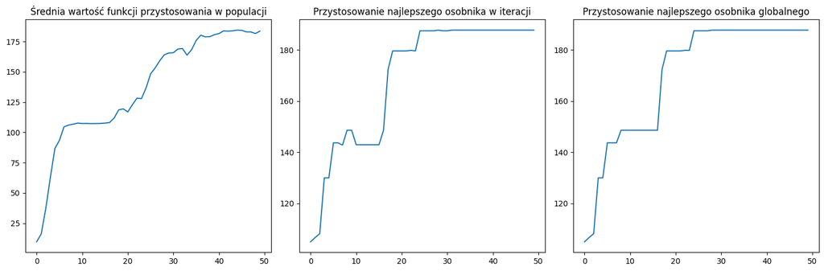

```
RUN 8
RUN 9
RUN 10
Average best adaptation from 10 runs: 173.777683
Average best solution: 0.01120096

------------------------------ SELECTION TYPE: treshold_30 ------------------------------
RUN 1
RUN 2
RUN 3
RUN 4
RUN 5
RUN 6
RUN 7
```

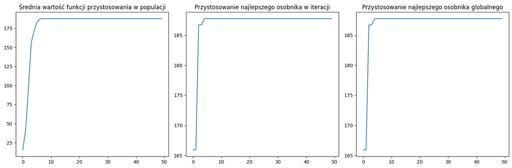

```
RUN 8
RUN 9
RUN 10
Average best adaptation from 10 runs: 159.958256
Average best solution: 0.04027782

------------------------------ SELECTION TYPE: treshold_60 ------------------------------
RUN 1
RUN 2
RUN 3
RUN 4
RUN 5
RUN 6
RUN 7
```

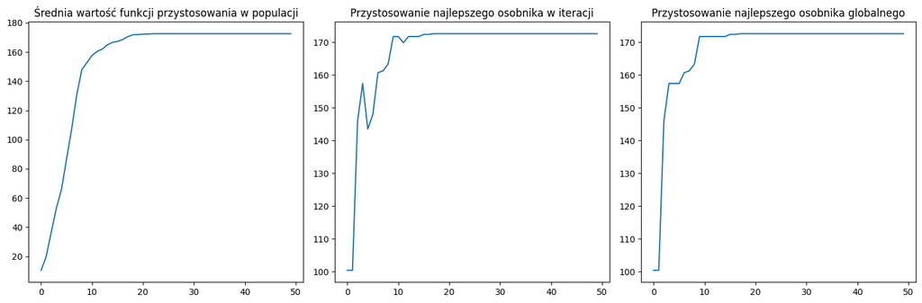

```
RUN 8
RUN 9
RUN 10
Average best adaptation from 10 runs: 148.328831
Average best solution: 0.01394127

------------------------------ MUTATION CHANCE: 0.1 ------------------------------
------------------------------ SELECTION TYPE: roulette ------------------------------
RUN 1
RUN 2
RUN 3
RUN 4
RUN 5
RUN 6
RUN 7
```

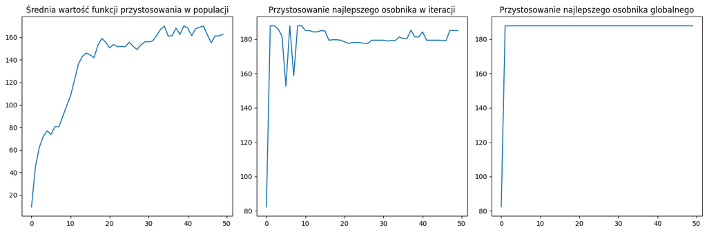

```
RUN 8
RUN 9
RUN 10
Average best adaptation from 10 runs: 186.286700
Average best solution: 0.01008762

------------------------------ SELECTION TYPE: treshold_30 ------------------------------
RUN 1
RUN 2
RUN 3
RUN 4
RUN 5
RUN 6
RUN 7
```

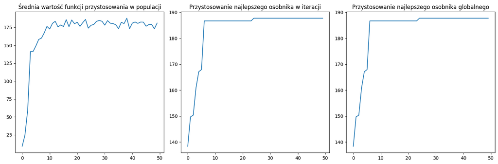

```
RUN 8
RUN 9
RUN 10
Average best adaptation from 10 runs: 187.740799
Average best solution: 0.01000000

------------------------------ SELECTION TYPE: treshold_60 ------------------------------
RUN 1
RUN 2
RUN 3
RUN 4
RUN 5
RUN 6
RUN 7
```

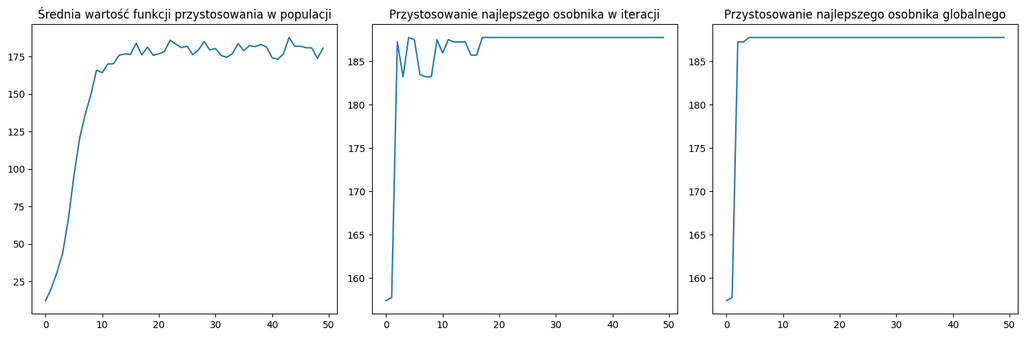

```
RUN 8
RUN 9
RUN 10
Average best adaptation from 10 runs: 187.740799
Average best solution: 0.01000000

------------------------------ MUTATION CHANCE: 0.5 ------------------------------
------------------------------ SELECTION TYPE: roulette ------------------------------
RUN 1
RUN 2
RUN 3
RUN 4
RUN 5
RUN 6
RUN 7
```

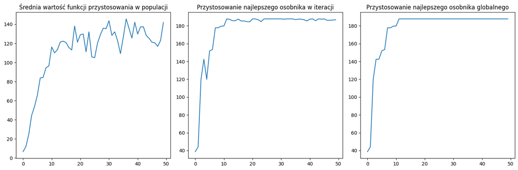

```
RUN 8
RUN 9
RUN 10
Average best adaptation from 10 runs: 187.714994
Average best solution: 0.01000151

------------------------------ SELECTION TYPE: treshold_30 ------------------------------
RUN 1
RUN 2
RUN 3
RUN 4
RUN 5
RUN 6
RUN 7
```

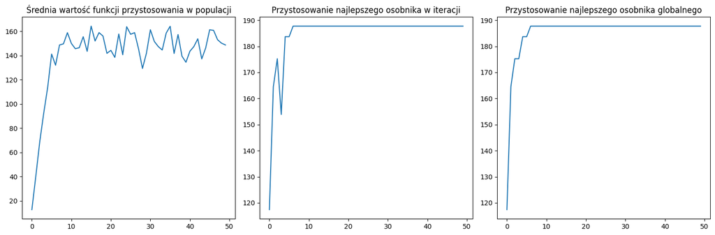

```
RUN 8
RUN 9
RUN 10
Average best adaptation from 10 runs: 187.740799
Average best solution: 0.01000000

------------------------------ SELECTION TYPE: treshold_60 ------------------------------
RUN 1
RUN 2
RUN 3
RUN 4
RUN 5
RUN 6
RUN 7
```

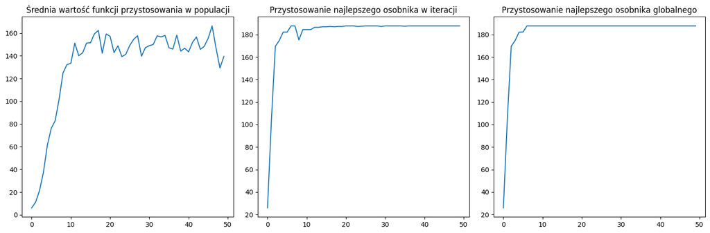

```
RUN 8
RUN 9
RUN 10
Average best adaptation from 10 runs: 187.740799
Average best solution: 0.01000000

------------------------------ MUTATION CHANCE: 1.0 ------------------------------
------------------------------ SELECTION TYPE: roulette ------------------------------
RUN 1
RUN 2
RUN 3
RUN 4
RUN 5
RUN 6
RUN 7
```

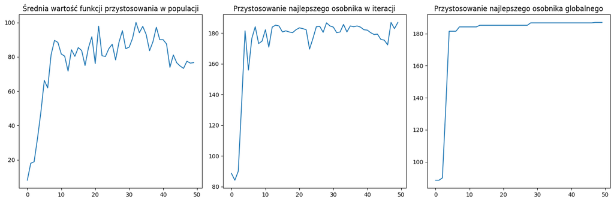

```
RUN 8
RUN 9
RUN 10
Average best adaptation from 10 runs: 187.689188
Average best solution: 0.01000302

------------------------------ SELECTION TYPE: treshold_30 ------------------------------
RUN 1
RUN 2
RUN 3
RUN 4
RUN 5
RUN 6
RUN 7
```

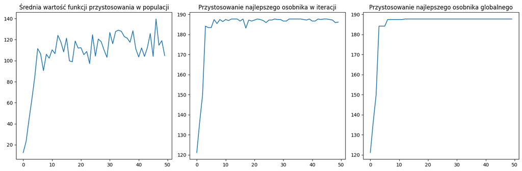

```
RUN 8
RUN 9
RUN 10
Average best adaptation from 10 runs: 187.740799
Average best solution: 0.01000000

------------------------------ SELECTION TYPE: treshold_60 ------------------------------
RUN 1
RUN 2
RUN 3
RUN 4
RUN 5
RUN 6
RUN 7
```

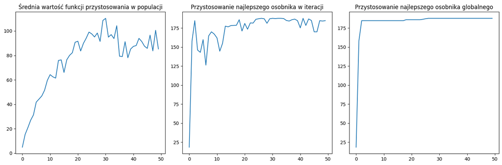

```
RUN 8
RUN 9
RUN 10
Average best adaptation from 10 runs: 187.689188
Average best solution: 0.01000302

------------------------------ CODING TYPE: gray ------------------------------
------------------------------ MUTATION CHANCE: 0 ------------------------------
------------------------------ SELECTION TYPE: roulette ------------------------------
RUN 1
RUN 2
RUN 3
RUN 4
RUN 5
RUN 6
RUN 7
```

[12 more figures not shown]

```
RUN 8
RUN 9
RUN 10
Average best adaptation from 10 runs: 187.586477
Average best solution: 0.01000906
```

```python
import numpy as np

mutation_chances = [0, 0.1, 0.5, 1.0]
codings = ['bin', 'gray']
selection_types = ['roulette', 'treshold_30', 'treshold_60']

for coding_type in codings:
  print(f'{print_dashes()} CODING TYPE: {coding_type} {print_dashes()}')
  for mutation_chance in mutation_chances:
    print(f'{print_dashes()} MUTATION CHANCE: {mutation_chance} {print_dashes()}')
    for selection_type in selection_types:
      print(f'{print_dashes()} SELECTION TYPE: {selection_type} {print_dashes()}')
      best_solutions = []
      best_adaptations = []
      for i in range(10):
        print(f'RUN {i+1}')
        if i == 6:
          best_solution, best_adaptation = run_algorithm(coding_type, mutation_chance, selection_type, show_plots = True)
        else:
          best_solution, best_adaptation = run_algorithm(coding_type, mutation_chance, selection_type)
        best_solutions.append(best_solution)
        best_adaptations.append(best_adaptation)
      avg_best_adaptation = np.mean(best_adaptations)
      avg_best_solution = sum(solution.get_number(kind=coding_type) for solution in best_solutions) / len(best_solutions)
      print(f'Average best adaptation from 10 runs: {avg_best_adaptation:.6f}')
      print(f'Average best solution: {avg_best_solution:.8f}')
      print()
```

Przykładowe przebiegi algorytmu na wykresach dla jednego z wywołań dla każdej konfiguracji:

## Wnioski

### Podsumowanie

Wykorzystanie kodowania binarnego ogólnie polepsza wyniki. Wtedy trzy typy selekcji szybko znajdują prawidłowe maksimum globalne przy odpowiednio dużej wartości prawdopodobieństwa mutacji, gdy dla kodowania gray'a, tylko threshold30 zwraca prawidłowe maksimum. Jeżeli musiałabym wybrać kodowanie gray'a dla tego problemu, wykorzystałabym selekcję treshold30 i mutację min 0.5. Dla takiego kodowania miałabym mniejsze pole wyboru rodzaju selekcji oraz wartości prawdopodobieństwa mutacji.

# ZAD 2

W mieście, reprezentowanym za pomocą kwadratowej siatki, operujemy siecią pizzerii. Ich lokalizacje znajdują się w kwadratach o pozycjach (1,1), (2,6), (5,4), (7,1), albo jak pokazano na obrazku poniżej.

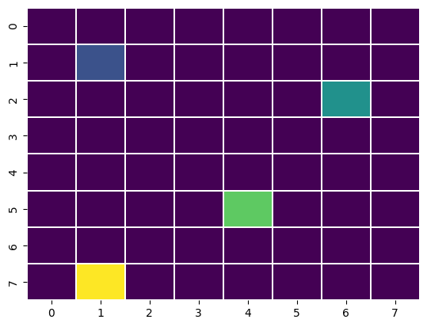

Zyski sieci zależą od budżetu wyłożonego na cztery pizzerie ($B_1$, $B_2$, $B_3$, $B_4$), gdzie każdy budżet jest w zakresie od **0 do 400** (nie może wyjść poza te wartości). Zysk jest liczony w następujący sposób:

$$ Z = \sum_{i=0}^8 \sum_{j=0}^8 \frac{z_{i,j}^1 + z_{i,j}^2 + z_{i,j}^3 + z_{i,j}^4}{4} - (B_1+B_2+B_3+B_4)^{1.15} $$

Gdzie $z_{i,j}^k$ jest dochodem $k$-tej pizzerii na polu $(i,j)$. Innymi słowy, sumujemy **średnie zyski** z danego pola dla wszystkich pizzerii i odejmujemy od tego skorygowaną (potęgowaną) sumę budżetów — ze względu na konieczność rozbudowy lokali, większe trudności w utrzymaniu itp.

Zysk $k$-tej pizzerii na polu $(i,j)$ liczymy natomiast następująco:

Najpierw liczymy $d$, czyli odległość taksówkarską (taxicab, Manhattan Distance) między pizzerią a tym polem.

- Jeżeli $d$ jest **mniejsza** niż 2:

$$ z = 1.3 \cdot \frac{B}{0.5d + 4} $$

- Jeżeli $d$ jest **większa lub równa** 2:

$$ z = \frac{B}{0.5d + 4} $$

Proszę zaprojektować **algorytm genetyczny**, który otrzyma jak najwyższą wartość funkcji $Z(B_1, B_2, B_3, B_4)$ i przedstawić, jak radzi sobie przy 10 wywołaniach (jak wygląda średnia wyniku i odchylenie standardowe).

Proszę samodzielnie wybrać **kodowanie** (rzeczywistoliczbowe, całkowitoliczbowe, binarne), wybrać **algorytm mutacji i selekcji**, oraz przeprowadzić **testy parametrów**.

```python
class PizzeriaSolution:
  shops = [(1,1), (2,6), (5,4), (7,1)]

  def __init__(self):
    self.B1 = random.randint(0,400)
    self.B2 = random.randint(0,400)
    self.B3 = random.randint(0,400)
    self.B4 = random.randint(0,400)
    self.genes = [self.B1, self.B2, self.B3, self.B4]

  @staticmethod
  def manhattan_distance(p1, p2):
    return abs(p1[0]-p2[0]) + abs(p1[1]-p2[1])

  def calculate_z(self):
    total_profit = 0.
    for i in range(8):
      for j in range(8):
        cell_profit = 0
        for k in range(4):
          d = self.manhattan_distance((i, j), PizzeriaSolution.shops[k])
          if d<2:
            z = 1.3*self.genes[k]/(0.5*d+4)
          else:
            z = self.genes[k]/(0.5*d+4)
          cell_profit += z
        total_profit += cell_profit
    return total_profit/4

  def get_adaptation(self):
      profit = self.calculate_z()
      substract = sum(self.genes)**1.15
      return profit-substract

  def crossover(self, other_solution):
    crossober_point = random.randint(1,4)
    new_solution = PizzeriaSolution()
    new_solution.genes = self.genes[:crossober_point] + other_solution.genes[crossober_point:]
    return new_solution

  # random resetting mutation: https://www.naukri.com/code360/library/mutation-in-genetic-algorithm
  def mutation(self, mutation_chance):
    for i in range(4):
      if random.random() < mutation_chance:
        self.genes[i] = random.randint(0,400)

  def __str__(self):
    return f'[{self.B1}, {self.B2}, {self.B3}, {self.B4}] : {self.get_adaptation()}'
```

```python
def run_algorithm(mutation_chance, selection_type,population_size ,print_details = True, iterations = 100):
  population = [PizzeriaSolution() for i in range(population_size)]
  best_solution = PizzeriaSolution()
  best_solution_adaptation = 0.
  best_iteration_found = 0

  for iteration in range(iterations):
    adaptations = [p.get_adaptation() for p in population]
    local_best_solution = population[adaptations.index(max(adaptations))]
    if local_best_solution.get_adaptation() > best_solution_adaptation:
      best_solution = local_best_solution
      best_solution_adaptation = local_best_solution.get_adaptation()
      best_iteration_found = iteration

    if selection_type == 'roulette':
      roulette_wheel = adaptations
      for i in range(len(roulette_wheel)):
        roulette_wheel[i] -= min(adaptations)
        roulette_wheel[i] /= (max(adaptations)-min(adaptations))

      parents = [random.choices(population, weights=roulette_wheel, k = 2) for i in range(population_size)]
      children = [p[0].crossover(p[1]) for p in parents]

    else:
      threshold_value = round(int(selection_type[-2:])/100*population_size)
      best_candidates = sorted(population, key=lambda x: x.get_adaptation(), reverse=True)[:threshold_value]
      parents = [random.choices(best_candidates, k=2) for i in range(population_size)]
      children = [p[0].crossover(p[1]) for p in parents]

    for c in children:
        c.mutation(mutation_chance)
    population = children

  adaptations = [p.get_adaptation() for p in population]
  local_best_solution = population[adaptations.index(max(adaptations))]
  if local_best_solution.get_adaptation() > best_solution_adaptation:
    best_solution = local_best_solution
    best_solution_adaptation = local_best_solution.get_adaptation()

  if print_details:
    print(f'Best solution: {best_solution}')

  return best_solution, best_solution_adaptation
```

```python
import numpy as np

mutation_chances = [0.2, 0.5]
selection_types = ['roulette', 'treshold_30', 'treshold_60']
population_size = 100

for mutation_chance in mutation_chances:
  print(f'{print_dashes()} MUTATION CHANCE: {mutation_chance} {print_dashes()}')
  for selection_type in selection_types:
    print(f'{print_dashes()} SELECTION TYPE: {selection_type} {print_dashes()}')
    best_adaptations = []
    for i in range(10):
      print(f'RUN {i+1}', end = '\t')
      _, best_adaptation = run_algorithm(mutation_chance, selection_type, population_size)
      best_adaptations.append(best_adaptation)
    avg_best_adaptation = np.mean(best_adaptations)
    std = np.std(best_adaptations)
    print(f'Średnia wyniku i odchylenie standardowe: {avg_best_adaptation:.4f}, {std:.4f}')
    print()
```

```
------------------------------ MUTATION CHANCE: 0.2 ------------------------------
------------------------------ SELECTION TYPE: roulette ------------------------------
RUN 1	Best solution: [345, 71, 23, 102] : 121.09660317652231
RUN 2	Best solution: [112, 400, 172, 227] : 122.93776735901054
RUN 3	Best solution: [243, 236, 62, 344] : 121.16538203800212
RUN 4	Best solution: [246, 33, 214, 154] : 122.24953745673076
RUN 5	Best solution: [138, 196, 10, 29] : 120.51040947397803
RUN 6	Best solution: [359, 354, 138, 40] : 119.80783987617554
RUN 7	Best solution: [364, 253, 50, 370] : 119.30434222886674
RUN 8	Best solution: [217, 33, 14, 111] : 121.14245535747921
RUN 9	Best solution: [142, 219, 56, 236] : 123.19045273638312
RUN 10	Best solution: [330, 34, 361, 371] : 124.71441129397238
Średnia wyniku i odchylenie standardowe: 121.6119, 1.5735

------------------------------ SELECTION TYPE: treshold_30 ------------------------------
RUN 1	Best solution: [175, 330, 355, 69] : 126.35319995957025
RUN 2	Best solution: [107, 130, 335, 140] : 126.35528432627405
RUN 3	Best solution: [353, 59, 15, 49] : 126.2304593719839
RUN 4	Best solution: [173, 91, 10, 180] : 126.15126074123702
RUN 5	Best solution: [75, 47, 232, 169] : 126.35528432627405
RUN 6	Best solution: [118, 383, 356, 292] : 126.35483692511536
RUN 7	Best solution: [135, 390, 204, 241] : 125.73964197307691
RUN 8	Best solution: [241, 239, 317, 397] : 126.35483692511536
RUN 9	Best solution: [337, 80, 177, 366] : 126.35528432627405
RUN 10	Best solution: [393, 372, 121, 110] : 126.35483692511536
Średnia wyniku i odchylenie standardowe: 126.2605, 0.1861

------------------------------ SELECTION TYPE: treshold_60 ------------------------------
RUN 1	Best solution: [236, 262, 149, 350] : 123.81177236631811
RUN 2	Best solution: [74, 91, 39, 103] : 122.4066495696967
RUN 3	Best solution: [278, 271, 304, 143] : 121.10118117784543
RUN 4	Best solution: [173, 99, 192, 57] : 125.40544282360736
RUN 5	Best solution: [145, 189, 165, 69] : 123.83679133214639
RUN 6	Best solution: [145, 14, 129, 375] : 124.17098339595645
RUN 7	Best solution: [384, 30, 218, 188] : 124.248118227806
RUN 8	Best solution: [253, 271, 312, 96] : 121.92819561531257
RUN 9	Best solution: [63, 191, 172, 368] : 123.51921707068834
RUN 10	Best solution: [83, 30, 14, 316] : 125.31715775356088
Średnia wyniku i odchylenie standardowe: 123.5746, 1.3236

```

[output cut: 24 more lines]

```
RUN 10	Best solution: [113, 126, 68, 83] : 122.08037038253269
Średnia wyniku i odchylenie standardowe: 122.4467, 1.0902

------------------------------ SELECTION TYPE: treshold_60 ------------------------------
RUN 1	Best solution: [292, 147, 335, 63] : 117.10018394943677
RUN 2	Best solution: [283, 140, 247, 366] : 120.56788800936022
RUN 3	Best solution: [263, 121, 147, 174] : 124.74111198548258
RUN 4	Best solution: [387, 100, 76, 354] : 118.5696884187505
RUN 5	Best solution: [164, 144, 75, 124] : 117.33166049413194
RUN 6	Best solution: [39, 224, 186, 158] : 117.60914032477172
RUN 7	Best solution: [260, 89, 396, 61] : 119.0547096865671
RUN 8	Best solution: [73, 304, 208, 154] : 117.0796648884525
RUN 9	Best solution: [251, 62, 324, 282] : 119.16584516887599
RUN 10	Best solution: [28, 95, 126, 109] : 121.63695838601757
Średnia wyniku i odchylenie standardowe: 119.2857, 2.3192
```

## Wnioski

```python
best_solution, best_adaptation = run_algorithm(0.2, 'threshold_30', 100)
```

```
Best solution: [162, 281, 67, 102] : 126.35454505261498
```